# 空间条纹-单细胞测试数据集1

Center for Cell Lineage and Atlas

## 1. 介绍

一般的单细胞测序流程需要将细胞从组织或器官中消化下来，该过程将失去细胞的空间定位信息。重建3D的空间基因表达，还原单细胞在空间中的定位是甲子项目最重要的目标。本项目拟结合胚胎条纹切割转录组测序，单细胞转录组测序，实现上述目标。然而，切割的条纹长度可横跨整个胚胎，当中包含多种细胞类型和大量细胞，与此同时，测序的单细胞覆盖度不足，数据存在大量噪音，令单细胞与条纹的匹配变得十分困难。为此，我们利用真实的空间单细胞定位数据模拟条纹和单细胞基因表达，作为测试数据集供各位研究者进行算法开发。

## 2. 测试数据

测试数据为小鼠小脑的空间单细胞基因表达谱，来源于2019年发表在Nature上的单细胞原位基因杂交法[seqFISH+](http://dx.doi.org/10.1038/s41586-019-1049-y)。单细胞数据共有10000个基因和523个细胞，6中不同的细胞类型。将空间划分成15个竖条(X轴向，自左往右依次标记为x1,…,x15)和7个横条(Y轴向，自下向上依次标记为y1,…,y7)，向单细胞基因表达往X轴向和Y轴向累加得到模拟的条纹基因表达。假设已知单细胞基因表达，条纹基因表达和两个轴向组成的网格的细胞数，重新将细胞定位回网格中并重构每个格子的平均基因表达。

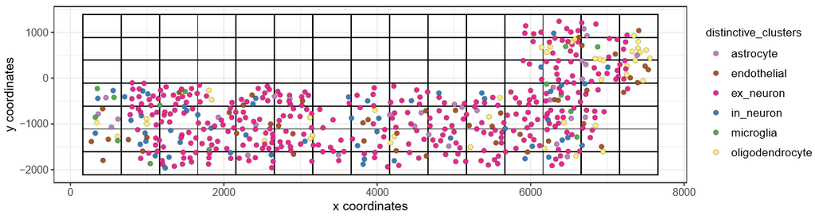

cell type in grid

## 3. 数据说明

### 3.1 加载数据

```r
library(Matrix)
library(dplyr)
library(ggplot2)
library(SingleCellExperiment)
```

下载数据

```r
# download.file("https://charliex210.github.io/docs/TestData1.RData",destfile = "TestData1.RData")
```

加载并查看数据

```r
load("E:/TestData1.RData")
ls()
```

```
## [1] "cell_num"      "grid_pos"      "scdata"        "spatial_de"
## [5] "true_grid_exp" "true_strip"
```

### 3.2 用于输入的数据

1. scdata: SingleCellExperiment对象，`colData(scData)`中包含细胞的空间位置，`assays(scdata)`中包含四个稀疏矩阵:
- true.counts: 真实的mRNA counts值
- counts: 带dropout的counts值(splatter模拟)
- true.normcounts: true.counts标准化后的基因表达
- normcounts: counts标准化后的基因表达
2. true_strip: 模拟的条纹基因表达(未标准化)
3. cell_num: 每个格子的细胞数

### 3.3 用于验证的数据

1. spatial_de: 空间差异表达基因(sort by Moran’s Index)
2. true_grid_exp: 每个格子真实的平均表达值(true_norm_counts)
3. grid_pos: true_grid_exp对应的空间位置

## 4. 评估方法

### 4.1 预测准确率

所有格子预测正确的细胞数占细胞总数的比例，1表示分类完全正确。

```r
accuracy <- function(true_cell_pool, recover_cell_pool) {
  nCells <- sum(sapply(true_cell_pool, length))
  correct_nCells <- c()
  for (idx in names(true_cell_pool)) {
    correct_nCells <- c(correct_nCells, length(intersect(true_cell_pool[[idx]], recover_cell_pool[[idx]])))
  }
  return(sum(correct_nCells)/nCells)
}
```

```r
true_cell_pool <- split(colnames(scdata), scdata$grid_id)
recover_cell_pool <- split(sample(colnames(scdata),ncol(scdata)), scdata$grid_id) # Random assignment
accuracy(true_cell_pool, recover_cell_pool)
```

```
## [1] 0.0210325
```

### 4.2 基因表达相关性

空间差异表达基因在重构和真实格子中的相关性，相关系数越高，重构的准确性越高。

```r
plot_corr_distrition <- function(true_grid_exp, recover_grid_exp, log=TRUE,
                                 genes = NULL, method="pearson") {
  if (log) {
    true_grid_exp <- log2(true_grid_exp + 1)
    recover_grid_exp <- log2(recover_grid_exp + 1)
  }
  cn <- colnames(recover_grid_exp)
  common_genes <- intersect(rownames(true_grid_exp), rownames(recover_grid_exp))
  if (!is.null(genes)) {
    common_genes <- common_genes[common_genes %in% genes]
    sim <- diag(cor(t(true_grid_exp[common_genes, cn]), t(recover_grid_exp[common_genes, cn]), method = method))
  } else {
    sim <- diag(cor(t(true_grid_exp[common_genes, cn]), t(recover_grid_exp[common_genes, cn]), method = method))
  }
  m <- round(median(sim),2)
  data.frame(Correlation = sim) %>%
    ggplot(aes(Correlation)) +
    geom_density(position = "stack", alpha = 0.1, color = "black", fill = "purple") +
    scale_x_continuous(breaks=c(0, 0.2, 0.4, 0.6, 0.8, 1),limits=c(-0.1,1.1)) +
    theme_classic() + labs(y="Density", title = paste0("Median ",m," (",length(common_genes)," genes)"))
}
```

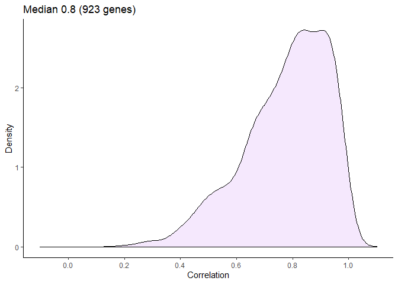

```r
true_grid_exp <- true_grid_exp
recover_grid_exp <- abs(jitter(true_grid_exp,factor = 50))# Add random noise
plot_corr_distrition(true_grid_exp, recover_grid_exp, genes=spatial_de, log = TRUE)
```